# abmR: An R Package for Agent-based Model Analysis of Large-scale Movements Across Taxa

Benjamin Gochanour, Javier Fernandez Lopez, Andrea Contina

2021-04-07

```r
library(abmr)
```

# 1 Getting Started

## 1.1 Installation

To use `abmR`, you must first install it from Github using `devtools` and load the library:

```r
#devtools: install_github("bgoch5/abmr")
library(abmr,quietly=TRUE,warn.conflicts=FALSE)
```

While this package is still in development, it will be updated frequently, so please be sure to re-install frequently. Installing `abmr` will also automaticaly install its dependencies, if you don’t already have them installed. These include `raster`, `sp`, `rgdal`, `table1`, `googledrive`, `swfscMisc`, `geosphere`, `kableExtra`, and `gtsummary`.

## 1.2 Requirements for Environmental Data Rasters and Species objects

The modeling functions discussed below require several input objects to work, which we will discuss here.

### 1.2.1 Environmental raster stack

Example data that will be used in this Vignette and other package documentation can be downloaded using `get_example_data()`. This function will download to your hard drive (to a location specified by your current working directory) the below NDVI raster files, totaling approximately 620 MB. The first time you use this function, you will be directed to your browser and required to sign in to your Google account to connect to the Tidyverse API. If you use the function a second time, you may simply follow the prompts and enter a number corresponding to the previous accounts listed.

```r
# get_ex_data() Commented out because can't run in non-interactive RMD session
```

Once you have the data downloaded, you must read it into R using commands like the following. You may instead use your own environmental raster data - NDVI or otherwise - and read it into R in a similar way.

```r
ndvi_raster_NA=stack("C:\\Users\\BGOCHANOUR\\Documents\\GitHub\\move-model\\NDVI_2013_NA.gri")
ndvi_raster_NA_composite=stack("C:\\Users\\BGOCHANOUR\\Documents\\GitHub\\move-model\\NDVI_2013_NA_composite.gri")
ndvi_raster_EU=stack("C:\\Users\\BGOCHANOUR\\Documents\\GitHub\\move-model\\NDVI_2013_Europe.gri")
ndvi_raster_EU_composite=stack("C:\\Users\\BGOCHANOUR\\Documents\\GitHub\\move-model\\NDVI_2013_Europe_composite.gri")
```

We can now quickly examine our raster data to see if it read in correctly.

First, we plot the Rasters for North America. The first raster is a 27-layer stack (of which we will plot the first four layers), and the second is a composite raster formed by taking the mean of all layers.

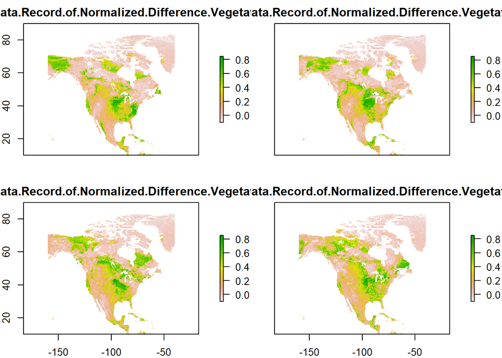

```r
plot(ndvi_raster_NA[[1:4]]) # First four layers of 27 layer RasterStack
```

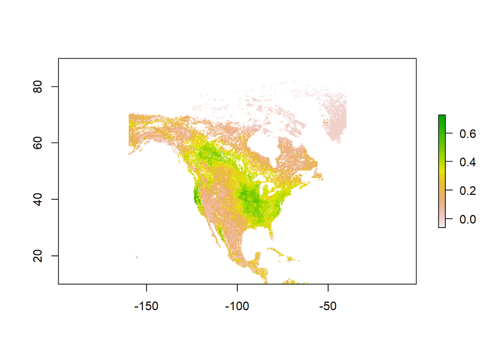

```r
plot(ndvi_raster_NA_composite) # This is average of above 27 layer raster
```

Next, plot the European data.

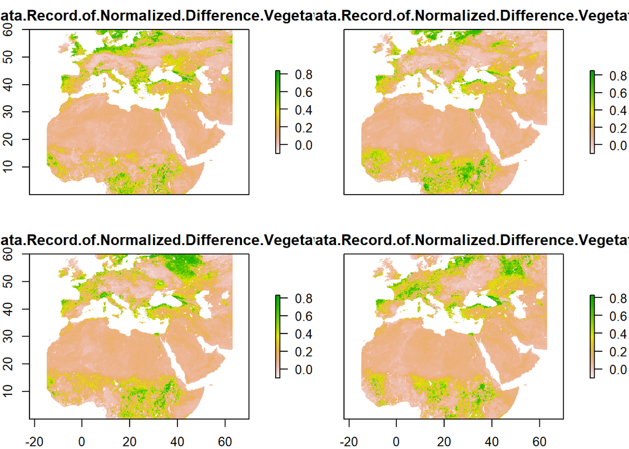

```r
plot(ndvi_raster_EU[[1:4]]) # First four layers of 27 layer RasterStack
```

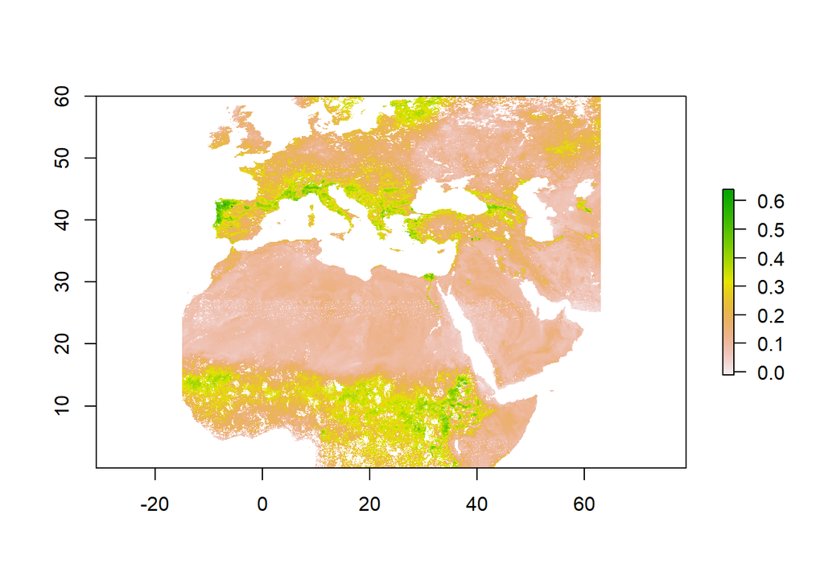

```r
plot(ndvi_raster_EU_composite)
```

### 1.2.2 Species object

This object will be constructed with the function `as.species`, and contains information on origin longitude (x) and latitude (y) as well as two morphological parameters, `p1` and `p2`. Use `?as.species` for more details.

Here, we will construct two example species, one for North America and one for Europe.

```r
NA.pop = as.species(x=-98.7, y=34.7, morphpar1=15, morphpar1mean=16,
                      morphpar1sd=2,morphpar1sign="Pos",
                      morphpar2=19,morphpar2mean=18,morphpar2sd=1,morphpar2sign="Pos")

EU.pop = as.species(x=10, y=50, morphpar1=24, morphpar1mean=16,
                        morphpar1sd=5,morphpar1sign="Pos", morphpar2=12, morphpar2mean=9,
                        morphpar2sd=3, morphpar2sign="Neg")
```

```r
# Small fig.width
# include_graphics("OCWA.jpg") Update pictures later
```

# 2 Running Agent-based models

`abmR` has two functions for modeling animal migration: `moveSIM` and `energySIM`. Both `moveSIM` and `energySIM` will output two things: (1) a dataframe of results (`$results`) and (2) a summary table of input parameters used (`$run_params`). For more details on how each function works, please see the documentation by using ?moveSIM or ?energySIM.

We will run `moveSIM` and `energySIM` once for each of our species, for a total of four movement simulations.

## 2.1 `moveSIM`

```r
NA.move=moveSIM(replicates=25,days=27,env_rast=ndvi_raster_NA, search_radius=550,
                sigma=.1, dest_x=-108.6, dest_y=26.2, mot_x=.8,
                mot_y=.8,modeled_species=NA.pop,optimum=.6, n_failures=3, fail_thresh=.40,
                direction="S",write_results=TRUE,single_rast=FALSE,mortality = T)
```

[output not shown]

```r
EU.move=moveSIM(replicates = 25, days=27, env_rast=ndvi_raster_EU, search_radius=550, sigma=0.1,
               dest_x=999, dest_y=999, mot_x=0.7, mot_y=0.7,
               modeled_species=EU.pop, optimum = 0.5, direction="S", write_results=F,
               single_rast=F, mortality = F, n_failures = 27, fail_thresh = 0.50)
```

[output not shown]

We can simply view our results in the console by typing `NA.move` or `EU.move`. However, we have created the function `tidy_results()` to provide cleaner output. Simply supply your moveSIM() or energySIM() output and specify `type`=“results” or `type`=“run_params”, depending on which portion of your output you’d like to display.

First, we run this function on our North American `moveSIM()` output. We will print just the first 35 rows to save space.

```r
tidy_results(NA.move,type="results",nrows=35)
```

|  | agent_id | day | lon | lat | curr_status | distance |
| --- | --- | --- | --- | --- | --- | --- |
| 1 | Agent_1 | 0 | -98.700 | 34.700 | Alive | NA |
| 2 | Agent_1 | 1 | -99.925 | 33.325 | Alive | 190.274 |
| 3 | Agent_1 | 2 | -93.325 | 31.675 | Alive | 646.156 |
| 4 | Agent_1 | 3 | -97.575 | 28.275 | Alive | 557.756 |
| 5 | Agent_1 | 4 | -102.825 | 23.225 | Alive | 769.919 |
| 6 | Agent_1 | 5 | -104.625 | 22.475 | Alive | 202.645 |
| 7 | Agent_1 | 6 | -101.575 | 20.625 | Alive | 376.988 |
| 8 | Agent_1 | 7 | -101.525 | 20.425 | Alive | 22.866 |
| 9 | Agent_1 | 8 | NA | NA | Stopped | NA |
| 10 | Agent_1 | 9 | NA | NA | Stopped | NA |
| 11 | Agent_1 | 10 | NA | NA | Stopped | NA |
| 12 | Agent_1 | 11 | NA | NA | Stopped | NA |
| 13 | Agent_1 | 12 | NA | NA | Stopped | NA |
| 14 | Agent_1 | 13 | NA | NA | Stopped | NA |
| 15 | Agent_1 | 14 | NA | NA | Stopped | NA |
| 16 | Agent_1 | 15 | NA | NA | Stopped | NA |
| 17 | Agent_1 | 16 | NA | NA | Stopped | NA |
| 18 | Agent_1 | 17 | NA | NA | Stopped | NA |
| 19 | Agent_1 | 18 | NA | NA | Stopped | NA |
| 20 | Agent_1 | 19 | NA | NA | Stopped | NA |
| 21 | Agent_1 | 20 | NA | NA | Stopped | NA |
| 22 | Agent_1 | 21 | NA | NA | Stopped | NA |
| 23 | Agent_1 | 22 | NA | NA | Stopped | NA |
| 24 | Agent_1 | 23 | NA | NA | Stopped | NA |
| 25 | Agent_1 | 24 | NA | NA | Stopped | NA |
| 26 | Agent_1 | 25 | NA | NA | Stopped | NA |
| 27 | Agent_1 | 26 | NA | NA | Stopped | NA |
| 28 | Agent_1 | 27 | NA | NA | Stopped | NA |
| 29 | Agent_2 | 0 | -98.700 | 34.700 | Alive | NA |
| 30 | Agent_2 | 1 | -106.825 | 32.475 | Alive | 792.841 |
| 31 | Agent_2 | 2 | -108.325 | 27.075 | Alive | 618.326 |
| 32 | Agent_2 | 3 | -108.525 | 26.125 | Alive | 107.611 |
| 33 | Agent_2 | 4 | -108.575 | 25.975 | Alive | 17.431 |
| 34 | Agent_2 | 5 | NA | NA | Stopped | NA |
| 35 | Agent_2 | 6 | NA | NA | Stopped | NA |

```r
tidy_results(NA.move,type="run_params")
```

|  | Param value |
| --- | --- |
| replicates | 25 |
| days | 27 |
| env_raster | env_raster |
| search_radius | 550 |
| sigma | 0.1 |
| dest_x | -108.6 |
| dest_y | 26.2 |
| mot_x | 0.8 |
| mot_y | 0.8 |
| modeled_species | NA.pop |
| optimum | 0.6 |
| n_failures | 3 |
| direction | S |
| mortality | TRUE |
| write_results | TRUE |
| single_rast | FALSE |
| missing_pct | 73.5714285714286 |
| mortality_pct | 0 |

Now, let’s examine our European `moveSIM()` output.

```r
tidy_results(EU.move,type="results",nrows=35)
```

|  | agent_id | day | lon | lat | curr_status | distance |
| --- | --- | --- | --- | --- | --- | --- |
| 1 | Agent_1 | 0 | 10.000 | 50.000 | Alive | NA |
| 2 | Agent_1 | 1 | 13.475 | 43.375 | Alive | 783.553 |
| 3 | Agent_1 | 2 | NA | NA | Stopped | NA |
| 4 | Agent_1 | 3 | NA | NA | Stopped | NA |
| 5 | Agent_1 | 4 | NA | NA | Stopped | NA |
| 6 | Agent_1 | 5 | NA | NA | Stopped | NA |
| 7 | Agent_1 | 6 | NA | NA | Stopped | NA |
| 8 | Agent_1 | 7 | NA | NA | Stopped | NA |
| 9 | Agent_1 | 8 | NA | NA | Stopped | NA |
| 10 | Agent_1 | 9 | NA | NA | Stopped | NA |
| 11 | Agent_1 | 10 | NA | NA | Stopped | NA |
| 12 | Agent_1 | 11 | NA | NA | Stopped | NA |
| 13 | Agent_1 | 12 | NA | NA | Stopped | NA |
| 14 | Agent_1 | 13 | NA | NA | Stopped | NA |
| 15 | Agent_1 | 14 | NA | NA | Stopped | NA |
| 16 | Agent_1 | 15 | NA | NA | Stopped | NA |
| 17 | Agent_1 | 16 | NA | NA | Stopped | NA |
| 18 | Agent_1 | 17 | NA | NA | Stopped | NA |
| 19 | Agent_1 | 18 | NA | NA | Stopped | NA |
| 20 | Agent_1 | 19 | NA | NA | Stopped | NA |
| 21 | Agent_1 | 20 | NA | NA | Stopped | NA |
| 22 | Agent_1 | 21 | NA | NA | Stopped | NA |
| 23 | Agent_1 | 22 | NA | NA | Stopped | NA |
| 24 | Agent_1 | 23 | NA | NA | Stopped | NA |
| 25 | Agent_1 | 24 | NA | NA | Stopped | NA |
| 26 | Agent_1 | 25 | NA | NA | Stopped | NA |
| 27 | Agent_1 | 26 | NA | NA | Stopped | NA |
| 28 | Agent_1 | 27 | NA | NA | Stopped | NA |
| 29 | Agent_2 | 0 | 10.000 | 50.000 | Alive | NA |
| 30 | Agent_2 | 1 | 8.675 | 45.825 | Alive | 475.136 |
| 31 | Agent_2 | 2 | 9.475 | 45.275 | Alive | 87.394 |
| 32 | Agent_2 | 3 | 15.225 | 44.175 | Alive | 470.856 |
| 33 | Agent_2 | 4 | 21.725 | 42.175 | Alive | 572.514 |
| 34 | Agent_2 | 5 | 21.625 | 39.575 | Alive | 289.553 |
| 35 | Agent_2 | 6 | 22.525 | 38.425 | Alive | 149.833 |

```r
tidy_results(EU.move,type="run_params")
```

|  | Param value |
| --- | --- |
| replicates | 25 |
| days | 27 |
| env_raster | env_raster |
| search_radius | 550 |
| sigma | 0.1 |
| dest_x | 999 |
| dest_y | 999 |
| mot_x | 0.7 |
| mot_y | 0.7 |
| modeled_species | EU.pop |
| optimum | 0.5 |
| n_failures | 27 |
| direction | S |
| mortality | FALSE |
| write_results | FALSE |
| single_rast | FALSE |
| missing_pct | 83.4285714285714 |
| mortality_pct | 0 |

## 2.2 `energySIM`

```r
NA.energy = energySIM(replicates=25,days=27,env_rast=ndvi_raster_NA, search_radius=550,
              sigma=.1, dest_x=-108.6, dest_y=26.2, mot_x=.8, mot_y=.8,
              modeled_species=NA.pop,
              optimum_lo=.4,optimum_hi=.8,init_energy=100,
              direction="S",write_results=FALSE,single_rast=FALSE,mortality = TRUE)
```

[output not shown]

```r
# matching up params as much as possible to moveSIM() stuff above
EU.energy = energySIM(replicates = 25, days=27, env_rast=ndvi_raster_EU, search_radius=550,
                      sigma=0.1, dest_x=999, dest_y=999, mot_x=0.7, mot_y=0.7,
               modeled_species=EU.pop, optimum_lo = 0.4, optimum_hi=0.6, init_energy=100,
               direction="S", write_results=F, single_rast=F, mortality = F)
```

[output not shown]

The `tidy_results` function will also work on `energySIM()` output.

First, we run this function on our North American `energySIM()` output.

```r
tidy_results(NA.energy,type="results",nrows=35)
```

|  | agent_id | day | lon | lat | curr_status | energy | delta_energy | distance |
| --- | --- | --- | --- | --- | --- | --- | --- | --- |
| 1 | Agent_1 | 0 | -98.700 | 34.700 | Alive | 100 | NA | NA |
| 2 | Agent_1 | 1 | -101.775 | 31.375 | Alive | 100 | 0 | 468.284 |
| 3 | Agent_1 | 2 | -107.525 | 27.025 | Alive | 85 | -15 | 739.143 |
| 4 | Agent_1 | 3 | -108.525 | 26.425 | Alive | 75 | -10 | 119.778 |
| 5 | Agent_1 | 4 | -108.425 | 26.375 | Alive | 85 | 10 | 11.419 |
| 6 | Agent_1 | 5 | -108.525 | 26.225 | Alive | 100 | 15 | 19.453 |
| 7 | Agent_1 | 6 | -108.575 | 26.175 | Alive | 100 | 0 | 7.478 |
| 8 | Agent_1 | 7 | -108.525 | 26.075 | Alive | 100 | 0 | 12.202 |
| 9 | Agent_1 | 8 | -108.575 | 25.925 | Alive | 100 | 0 | 17.431 |
| 10 | Agent_1 | 9 | NA | NA | Stopped | NA | NA | NA |
| 11 | Agent_1 | 10 | NA | NA | Stopped | NA | NA | NA |
| 12 | Agent_1 | 11 | NA | NA | Stopped | NA | NA | NA |
| 13 | Agent_1 | 12 | NA | NA | Stopped | NA | NA | NA |
| 14 | Agent_1 | 13 | NA | NA | Stopped | NA | NA | NA |
| 15 | Agent_1 | 14 | NA | NA | Stopped | NA | NA | NA |
| 16 | Agent_1 | 15 | NA | NA | Stopped | NA | NA | NA |
| 17 | Agent_1 | 16 | NA | NA | Stopped | NA | NA | NA |
| 18 | Agent_1 | 17 | NA | NA | Stopped | NA | NA | NA |
| 19 | Agent_1 | 18 | NA | NA | Stopped | NA | NA | NA |
| 20 | Agent_1 | 19 | NA | NA | Stopped | NA | NA | NA |
| 21 | Agent_1 | 20 | NA | NA | Stopped | NA | NA | NA |
| 22 | Agent_1 | 21 | NA | NA | Stopped | NA | NA | NA |
| 23 | Agent_1 | 22 | NA | NA | Stopped | NA | NA | NA |
| 24 | Agent_1 | 23 | NA | NA | Stopped | NA | NA | NA |
| 25 | Agent_1 | 24 | NA | NA | Stopped | NA | NA | NA |
| 26 | Agent_1 | 25 | NA | NA | Stopped | NA | NA | NA |
| 27 | Agent_1 | 26 | NA | NA | Stopped | NA | NA | NA |
| 28 | Agent_1 | 27 | NA | NA | Stopped | NA | NA | NA |
| 29 | Agent_2 | 0 | -98.700 | 34.700 | Alive | 100 | NA | NA |
| 30 | Agent_2 | 1 | -93.075 | 32.975 | Alive | 100 | 0 | 554.323 |
| 31 | Agent_2 | 2 | -86.475 | 32.325 | Alive | 100 | 0 | 622.722 |
| 32 | Agent_2 | 3 | -82.825 | 31.525 | Alive | 100 | 0 | 356.149 |
| 33 | Agent_2 | 4 | -85.675 | 31.425 | Alive | 100 | 0 | 270.803 |
| 34 | Agent_2 | 5 | -88.875 | 30.625 | Alive | 100 | 0 | 317.972 |
| 35 | Agent_2 | 6 | -92.975 | 30.225 | Alive | 100 | 0 | 396.047 |

```r
tidy_results(NA.energy,type="run_params")
```

|  | Param value |
| --- | --- |
| replicates | 25 |
| days | 27 |
| env_raster | env_raster |
| search_radius | 550 |
| sigma | 0.1 |
| dest_x | -108.6 |
| dest_y | 26.2 |
| mot_x | 0.8 |
| mot_y | 0.8 |
| modeled_species | NA.pop |
| optimum_lo | 0.4 |
| optimum_hi | 0.8 |
| init_energy | 100 |
| direction | S |
| mortality | TRUE |
| write_results | FALSE |
| single_rast | FALSE |
| missing_pct | 65.7142857142857 |
| mortality_pct | 0 |

Now, let’s examine our European `energySIM()` output.

```r
tidy_results(EU.energy,type="results", nrows=35)
```

|  | agent_id | day | lon | lat | curr_status | energy | delta_energy | distance |
| --- | --- | --- | --- | --- | --- | --- | --- | --- |
| 1 | Agent_1 | 0 | 10.000 | 50.000 | Alive | 100 | NA | NA |
| 2 | Agent_1 | 1 | 7.425 | 45.225 | Alive | 90 | -10 | 565.495 |
| 3 | Agent_1 | 2 | 8.675 | 42.325 | Alive | 100 | 10 | 338.088 |
| 4 | Agent_1 | 3 | 0.875 | 41.975 | Alive | 95 | -5 | 644.694 |
| 5 | Agent_1 | 4 | -5.775 | 41.875 | Alive | 100 | 5 | 550.753 |
| 6 | Agent_1 | 5 | -8.025 | 39.825 | Alive | 100 | 0 | 296.578 |
| 7 | Agent_1 | 6 | -6.025 | 39.625 | Alive | 100 | 0 | 172.674 |
| 8 | Agent_1 | 7 | -0.675 | 38.475 | Alive | 100 | 0 | 479.813 |
| 9 | Agent_1 | 8 | -5.625 | 38.275 | Alive | 95 | -5 | 432.510 |
| 10 | Agent_1 | 9 | NA | NA | Stopped | NA | NA | NA |
| 11 | Agent_1 | 10 | NA | NA | Stopped | NA | NA | NA |
| 12 | Agent_1 | 11 | NA | NA | Stopped | NA | NA | NA |
| 13 | Agent_1 | 12 | NA | NA | Stopped | NA | NA | NA |
| 14 | Agent_1 | 13 | NA | NA | Stopped | NA | NA | NA |
| 15 | Agent_1 | 14 | NA | NA | Stopped | NA | NA | NA |
| 16 | Agent_1 | 15 | NA | NA | Stopped | NA | NA | NA |
| 17 | Agent_1 | 16 | NA | NA | Stopped | NA | NA | NA |
| 18 | Agent_1 | 17 | NA | NA | Stopped | NA | NA | NA |
| 19 | Agent_1 | 18 | NA | NA | Stopped | NA | NA | NA |
| 20 | Agent_1 | 19 | NA | NA | Stopped | NA | NA | NA |
| 21 | Agent_1 | 20 | NA | NA | Stopped | NA | NA | NA |
| 22 | Agent_1 | 21 | NA | NA | Stopped | NA | NA | NA |
| 23 | Agent_1 | 22 | NA | NA | Stopped | NA | NA | NA |
| 24 | Agent_1 | 23 | NA | NA | Stopped | NA | NA | NA |
| 25 | Agent_1 | 24 | NA | NA | Stopped | NA | NA | NA |
| 26 | Agent_1 | 25 | NA | NA | Stopped | NA | NA | NA |
| 27 | Agent_1 | 26 | NA | NA | Stopped | NA | NA | NA |
| 28 | Agent_1 | 27 | NA | NA | Stopped | NA | NA | NA |
| 29 | Agent_2 | 0 | 10.000 | 50.000 | Alive | 100 | NA | NA |
| 30 | Agent_2 | 1 | 8.975 | 45.725 | Alive | 100 | 0 | 481.995 |
| 31 | Agent_2 | 2 | 8.975 | 42.125 | Alive | 80 | -20 | 400.750 |
| 32 | Agent_2 | 3 | NA | NA | Stopped | NA | NA | NA |
| 33 | Agent_2 | 4 | NA | NA | Stopped | NA | NA | NA |
| 34 | Agent_2 | 5 | NA | NA | Stopped | NA | NA | NA |
| 35 | Agent_2 | 6 | NA | NA | Stopped | NA | NA | NA |

```r
tidy_results(EU.energy,type="run_params")
```

|  | Param value |
| --- | --- |
| replicates | 25 |
| days | 27 |
| env_raster | env_raster |
| search_radius | 550 |
| sigma | 0.1 |
| dest_x | 999 |
| dest_y | 999 |
| mot_x | 0.7 |
| mot_y | 0.7 |
| modeled_species | EU.pop |
| optimum_lo | 0.4 |
| optimum_hi | 0.6 |
| init_energy | 100 |
| direction | S |
| mortality | FALSE |
| write_results | FALSE |
| single_rast | FALSE |
| missing_pct | 82.8571428571429 |
| mortality_pct | 0 |

# 3 Visualizing/Summarizing Results

The output from `moveSIM` and `energySIM` are simple dataframes, so one may easily visualize their results using custom codes. However, we have provided `moveVIZ` and `energyVIZ`, respectively, to provide pre-prepared solutions for visualizing and summarizing your movement simulation results. These functions will be demonstrated first for our North America results and second for our Europe results.

## 3.1 North American Results

The first two types of output are available for both `moveSIM()` and `energySIM()` output via the functions `moveVIZ()` and `energyVIZ()`, respectively.

### 3.1.1 Movement tracks

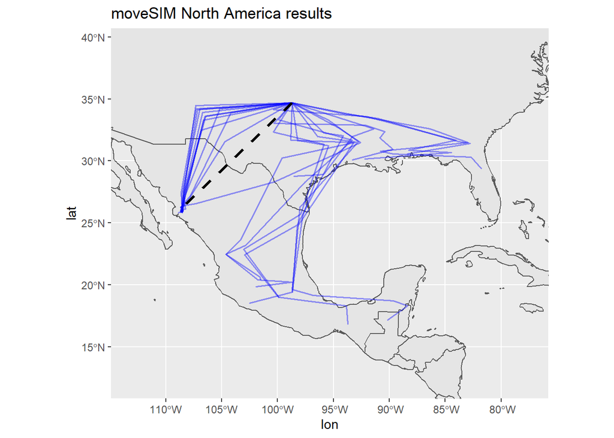

```r
moveVIZ(NA.move, type="plot", title="moveSIM North America results")
```

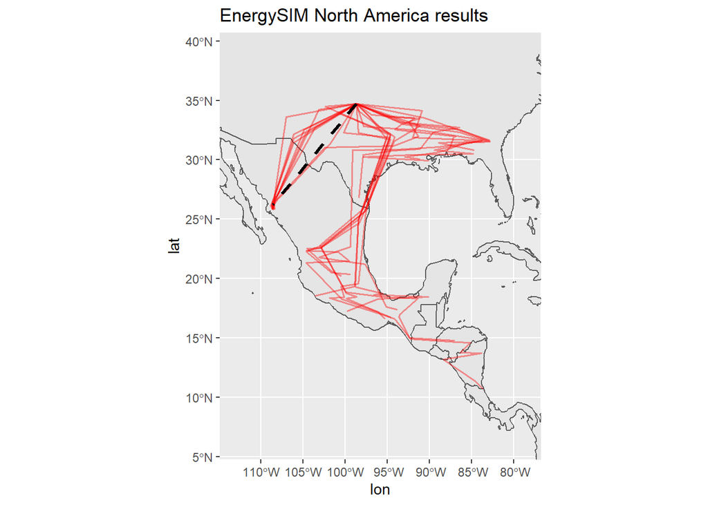

```r
energyVIZ(NA.energy, type="plot", title="EnergySIM North America results")
```

### 3.1.2 Summary table

```r
moveVIZ(NA.move, type="summary_table")
```

| **Characteristic** | **N = 700**<sup>1</sup> |
| --- | --- |
| lon | -102 (-108, -98) |
| Unknown | 515 |
| lat | 27.2 (26.0, 32.6) |
| Unknown | 515 |
| curr_status |  |
| Alive | 185 (26%) |
| Stopped | 515 (74%) |
| distance | 265 (26, 657) |
| Unknown | 540 |

<sup>*1*</sup> Median (IQR); n (%)

```r
energyVIZ(NA.energy, type="summary_table")
```

| **Characteristic** | **N = 700**<sup>1</sup> |
| --- | --- |
| lon | -99 (-108, -94) |
| Unknown | 460 |
| lat | 26.3 (25.4, 32.1) |
| Unknown | 460 |
| curr_status |  |
| Alive | 240 (34%) |
| Stopped | 460 (66%) |
| energy |  |
| 70 | 1 (0.4%) |
| 75 | 2 (0.8%) |
| 80 | 2 (0.8%) |
| 85 | 11 (4.6%) |
| 90 | 11 (4.6%) |
| 95 | 12 (5.0%) |
| 100 | 201 (84%) |
| Unknown | 460 |
| delta_energy |  |
| -15 | 4 (1.9%) |
| -10 | 13 (6.0%) |
| -5 | 16 (7.4%) |
| 0 | 160 (74%) |
| 5 | 2 (0.9%) |
| 10 | 11 (5.1%) |
| 15 | 7 (3.3%) |
| 20 | 2 (0.9%) |
| Unknown | 485 |
| distance | 289 (31, 559) |
| Unknown | 485 |

<sup>*1*</sup> Median (IQR); n (%)

The next two types of output are available only for `energySIM()` output.

### 3.1.3 Stratified tables

```r
energyVIZ(NA.energy, type="strat_table")
```

|  | -15 (N=4) | -10 (N=13) | -5 (N=16) | 0 (N=160) | 5 (N=2) | 10 (N=11) | 15 (N=7) | 20 (N=2) | Overall (N=700) |
| --- | --- | --- | --- | --- | --- | --- | --- | --- | --- |
| energy |  |  |  |  |  |  |  |  |  |
| Mean (SD) | 81.3 (7.50) | 85.4 (5.58) | 92.5 (3.65) | 99.9 (0.557) | 95.0 (7.07) | 95.5 (7.89) | 100 (0) | 100 (0) | 98.1 (4.99) |
| Median [Min, Max] | 85.0 [70.0, 85.0] | 85.0 [75.0, 90.0] | 95.0 [85.0, 95.0] | 100 [95.0, 100] | 95.0 [90.0, 100] | 100 [80.0, 100] | 100 [100, 100] | 100 [100, 100] | 100 [70.0, 100] |
| Missing | 0 (0%) | 0 (0%) | 0 (0%) | 0 (0%) | 0 (0%) | 0 (0%) | 0 (0%) | 0 (0%) | 460 (65.7%) |
| day |  |  |  |  |  |  |  |  |  |
| Mean (SD) | 5.50 (4.51) | 4.00 (2.58) | 4.69 (4.41) | 5.26 (3.12) | 7.00 (1.41) | 6.09 (3.81) | 6.57 (3.78) | 5.50 (0.707) | 13.5 (8.08) |
| Median [Min, Max] | 4.00 [2.00, 12.0] | 3.00 [2.00, 10.0] | 3.00 [1.00, 15.0] | 5.00 [1.00, 17.0] | 7.00 [6.00, 8.00] | 4.00 [4.00, 16.0] | 5.00 [4.00, 13.0] | 5.50 [5.00, 6.00] | 13.5 [0, 27.0] |
| distance |  |  |  |  |  |  |  |  |  |
| Mean (SD) | 306 (323) | 437 (334) | 468 (255) | 323 (265) | 64.6 (80.8) | 269 (291) | 33.8 (28.4) | 66.4 (64.5) | 323 (273) |
| Median [Min, Max] | 239 [7.48, 739] | 482 [19.5, 890] | 547 [20.8, 776] | 300 [5.57, 908] | 64.6 [7.48, 122] | 39.0 [11.4, 686] | 20.8 [19.4, 97.4] | 66.4 [20.7, 112] | 289 [5.57, 908] |
| Missing | 0 (0%) | 0 (0%) | 0 (0%) | 0 (0%) | 0 (0%) | 0 (0%) | 0 (0%) | 0 (0%) | 485 (69.3%) |

### 3.1.4 Gradient plots

```
#> [inverse distance weighted interpolation]
```

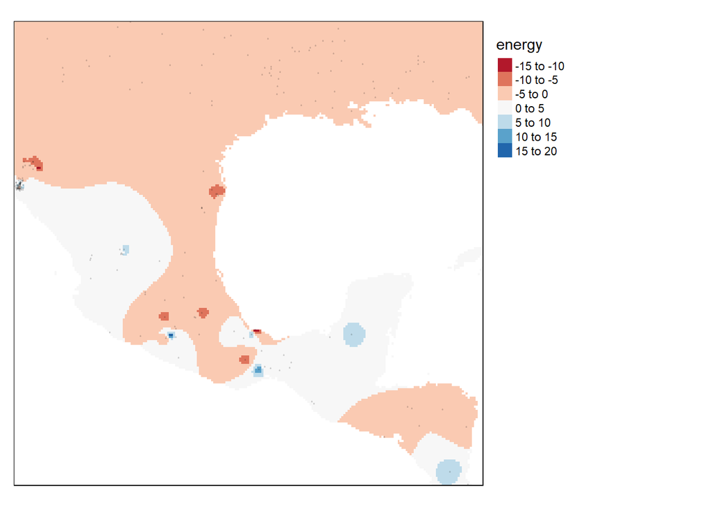

```r
energyVIZ(NA.energy, type="gradient")
```

## 3.2 European Results

### 3.2.1 Movement tracks

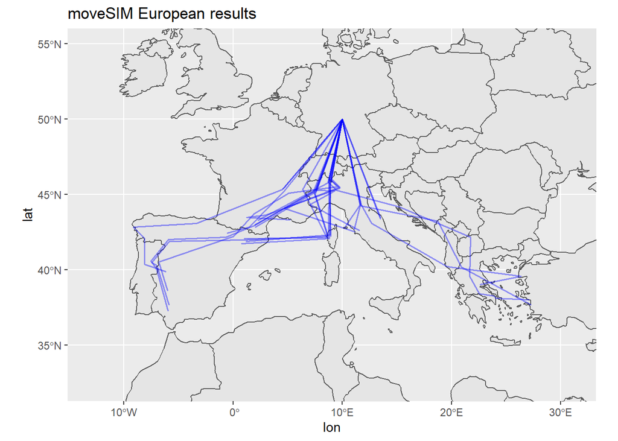

```r
moveVIZ(EU.move, type="plot", title="moveSIM European results")
```

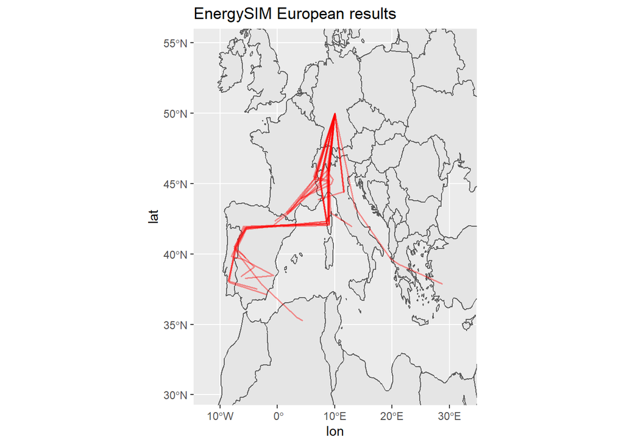

```r
energyVIZ(EU.energy, type="plot", title="EnergySIM European results")
```

### 3.2.2 Summary table

```r
moveVIZ(EU.move, type="summary_table")
```

| **Characteristic** | **N = 700**<sup>1</sup> |
| --- | --- |
| lon | 9 (3, 10) |
| Unknown | 584 |
| lat | 44.1 (42.2, 45.9) |
| Unknown | 584 |
| curr_status |  |
| Alive | 116 (17%) |
| Stopped | 584 (83%) |
| distance | 434 (216, 574) |
| Unknown | 609 |

<sup>*1*</sup> Median (IQR); n (%)

```r
energyVIZ(EU.energy, type="summary_table")
```

| **Characteristic** | **N = 700**<sup>1</sup> |
| --- | --- |
| lon | 8.0 (-0.5, 10.0) |
| Unknown | 580 |
| lat | 43.0 (41.9, 45.8) |
| Unknown | 580 |
| curr_status |  |
| Alive | 120 (17%) |
| Stopped | 580 (83%) |
| energy |  |
| 65 | 1 (0.8%) |
| 70 | 2 (1.7%) |
| 80 | 3 (2.5%) |
| 85 | 5 (4.2%) |
| 90 | 13 (11%) |
| 95 | 10 (8.3%) |
| 100 | 86 (72%) |
| Unknown | 580 |
| delta_energy |  |
| -20 | 2 (2.1%) |
| -15 | 2 (2.1%) |
| -10 | 12 (13%) |
| -5 | 12 (13%) |
| 0 | 52 (55%) |
| 5 | 6 (6.3%) |
| 10 | 5 (5.3%) |
| 15 | 3 (3.2%) |
| 20 | 1 (1.1%) |
| Unknown | 605 |
| distance | 452 (266, 574) |
| Unknown | 605 |

<sup>*1*</sup> Median (IQR); n (%)

The next two types of output are available only for `energySIM()` output.

### 3.2.3 Stratified tables

```r
energyVIZ(EU.energy, type="strat_table")
```

|  | -20 (N=2) | -15 (N=2) | -10 (N=12) | -5 (N=12) | 0 (N=52) | 5 (N=6) | 10 (N=5) | 15 (N=3) | 20 (N=1) | Overall (N=700) |
| --- | --- | --- | --- | --- | --- | --- | --- | --- | --- | --- |
| energy |  |  |  |  |  |  |  |  |  |  |
| Mean (SD) | 75.0 (7.07) | 82.5 (3.54) | 88.8 (3.11) | 90.4 (8.91) | 99.5 (2.27) | 93.3 (12.1) | 100 (0) | 100 (0) | 90.0 (NA) | 96.6 (6.80) |
| Median [Min, Max] | 75.0 [70.0, 80.0] | 82.5 [80.0, 85.0] | 90.0 [80.0, 90.0] | 95.0 [65.0, 95.0] | 100 [85.0, 100] | 100 [70.0, 100] | 100 [100, 100] | 100 [100, 100] | 90.0 [90.0, 90.0] | 100 [65.0, 100] |
| Missing | 0 (0%) | 0 (0%) | 0 (0%) | 0 (0%) | 0 (0%) | 0 (0%) | 0 (0%) | 0 (0%) | 0 (0%) | 580 (82.9%) |
| day |  |  |  |  |  |  |  |  |  |  |
| Mean (SD) | 2.00 (0) | 1.50 (0.707) | 1.58 (0.793) | 3.92 (2.78) | 3.37 (2.26) | 4.17 (0.408) | 3.40 (1.95) | 3.33 (1.53) | 5.00 (NA) | 13.5 (8.08) |
| Median [Min, Max] | 2.00 [2.00, 2.00] | 1.50 [1.00, 2.00] | 1.00 [1.00, 3.00] | 3.00 [1.00, 9.00] | 2.50 [1.00, 8.00] | 4.00 [4.00, 5.00] | 2.00 [2.00, 6.00] | 3.00 [2.00, 5.00] | 5.00 [5.00, 5.00] | 13.5 [0, 27.0] |
| distance |  |  |  |  |  |  |  |  |  |  |
| Mean (SD) | 404 (3.95) | 486 (105) | 550 (117) | 520 (185) | 379 (183) | 472 (130) | 383 (147) | 242 (124) | 240 (NA) | 421 (179) |
| Median [Min, Max] | 404 [401, 406] | 486 [412, 560] | 577 [395, 790] | 614 [84.7, 657] | 419 [6.81, 675] | 539 [224, 551] | 338 [238, 598] | 216 [132, 377] | 240 [240, 240] | 452 [6.81, 790] |
| Missing | 0 (0%) | 0 (0%) | 0 (0%) | 0 (0%) | 0 (0%) | 0 (0%) | 0 (0%) | 0 (0%) | 0 (0%) | 605 (86.4%) |

### 3.2.4 Gradient plots

```
#> [inverse distance weighted interpolation]
```

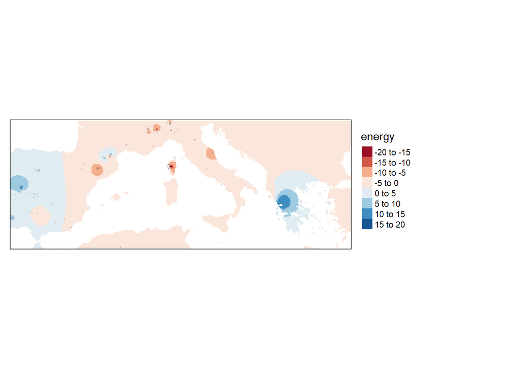

```r
energyVIZ(EU.energy, type="gradient")
```

# 4 Getting Help

Need help? Have suggestions to make `abmR` better? If so, please open an issue or pull request on Github (https://github.com/bgoch5/abmr), or drop me an email at ben.gochanour@ou.edu.